# Notebook

How computers store signals?

Signal; Digital signal; ADC; Sampling; Bit-depth; SQNR;

📋 Table of Contents

Signal

Analog to Digital Conversion (ADC)

Sampling

Quantization

SQNR

## Signal

A **signal** is anything that contains **information** and varies over time or location. This **variation** is what encapsulates information. If the signal is not varying, e.g. constant signal, there is not much information to learn from it.

A **signal** is **continuous** in nature, i.e. there is a value at every instant of time/space. However, a proof might be needed here.

Since a signal encapsulates behaviour of a system so analsing the signal becomes really important to understand the system. One can hypothetically analyse signal manually, by analysing values one-by-one but we do have computers to handle that tedious task of performing operations that too with better accuracy, speed and efficiency.

But there is a catch, in order to use *computers*, we have to store the signal into **memory** that computers can access. Since, signals that we deal with are continuous, there is no way to store that infinite amount of information in computer. There are various **quantization** that we have to perform to allow computers to store signal. Signal thus stored in computer is referred to as **digital signal**.

## ADC

The process of converting an analog/continuous signal into digital/discrete signal is called **ADC**. It stands for **Analog to Digital Conversion**. This process involves **quantization** of the signal so that they can be stored in computer.

### Sampling

Since we have limited memory to store signal in computer, we perform *sampling* which means that we only collect values of the analog signal at certain timepoints often equally spaced by say $T$ sec which is known as **sampling period** of the signal. The inverse of $T$ is called **sampling frequency** $f_s = \frac{1}{T}$ hz

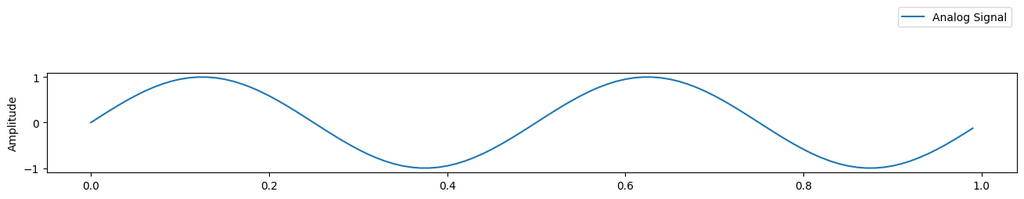

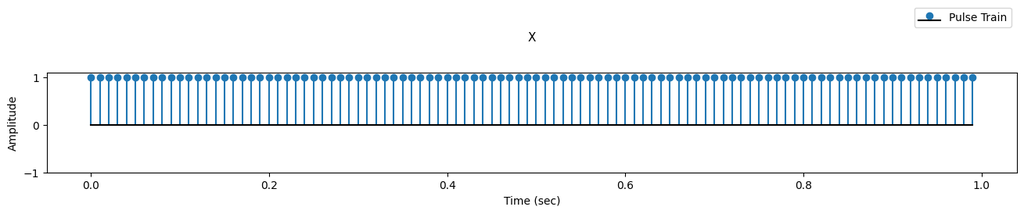

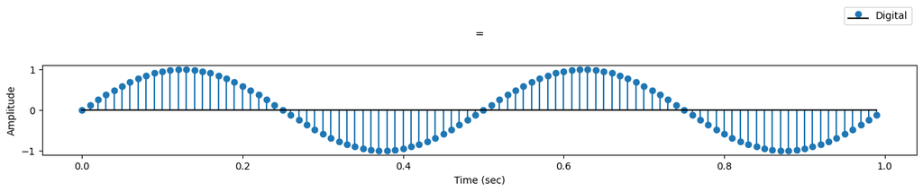

### Amplitude Quantization

All the values of the analog signal are rounded to the nearest bin computed as per the bit-depth.

The range of numbers for a given bit depth depends on the datatype used to store the values.

Due to this amplitude quantization, we get **quantisation error** leading to **quantization noise** This is often reported as sound-to-quantization-noise-ratio aka $SQNR$.

$SQNR \propto n $